# Recall performance for objects inside the rooms

# 1 Visual inspection of the data

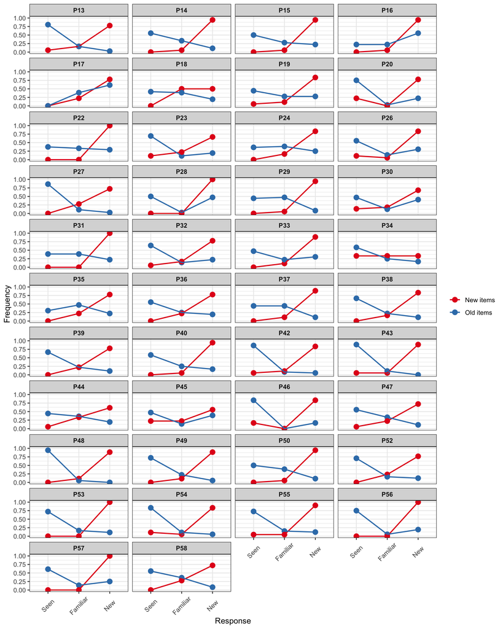

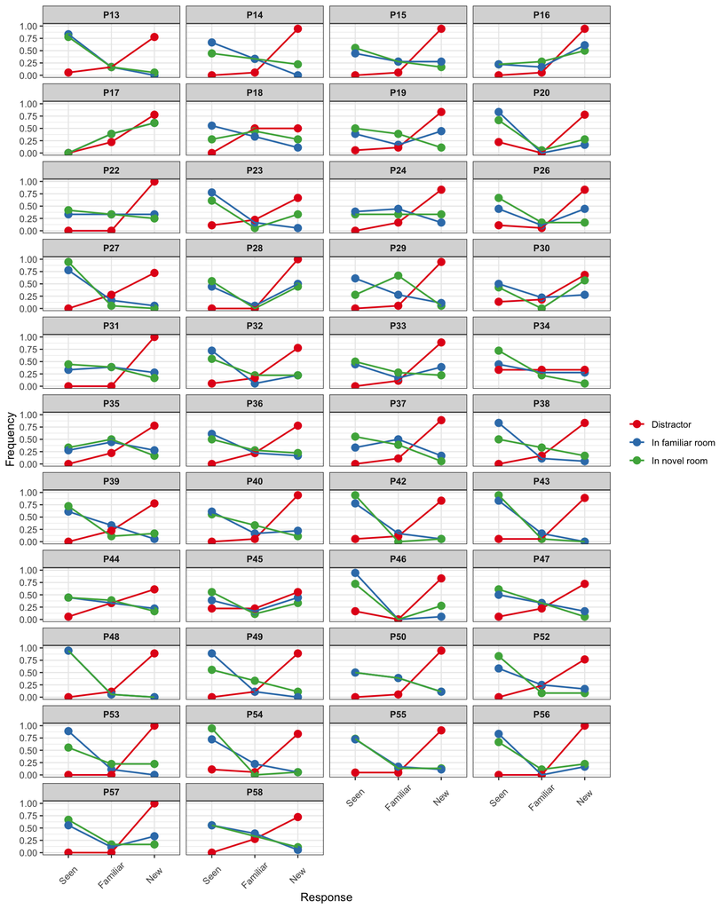

# 2 Novelty Benefits

## 2.1 Check the data

- **Is there any corrected hit rate < 0?**
  - There are 0 negative values.

## 2.2 Compare mean accuracy between *novel* and *familiar* rooms

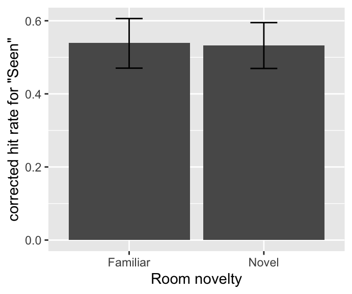

Figure1. Mean accuracy for item memory respectively for Familiar and Novel rooms.

```
##       Group      Mean        SD  N
## 1: Familiar 0.5399316 0.2236495 42
## 2:    Novel 0.5332045 0.2029982 42
```

```
##
##  Paired t-test
##
## data:  SAcc by Group
## t = 0.25075, df = 41, p-value = 0.8033
## alternative hypothesis: true difference in means is not equal to 0
## 95 percent confidence interval:
##  -0.04745400  0.06090827
## sample estimates:
## mean of the differences
##             0.006727135
```

## 2.3 Any difference between *Early* and *Later* object groups?

### 2.3.1 Check the data

- **Is there any corrected hit rate < 0?**
  - There are 0 negative values out of a total of 168 values.

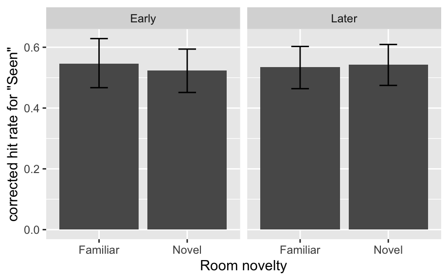

```
##       Group ObjOrdGrp      Mean        SD  N
## 1: Familiar     Early 0.5458840 0.2702848 42
## 2:    Novel     Early 0.5240586 0.2411724 42
## 3:    Novel     Later 0.5432385 0.2234802 42
## 4: Familiar     Later 0.5339792 0.2245803 42
```

```
## $ANOVA
##            Effect DFn DFd          F         p p<.05          ges
## 2           Group   1  41 0.05499103 0.8157627       1.745818e-04
## 3       ObjOrdGrp   1  41 0.01682100 0.8974413       5.852313e-05
## 4 Group:ObjOrdGrp   1  41 0.59960013 0.4431733       1.067332e-03
```

# 3 Curiosity Enhancement

## 3.1 Check the data

### 3.1.1 Is there any corrected hit rate < 0?

#### 3.1.1.1 For the data per room

- There are 1 negative values out of a total of 248 values.

```
##    SubjectNo Context    Group CurRating RoomOrder Duration     SFHit SHit
## 1:       P45 Library Familiar         7     First 205.2989 0.3333333    0
##       SrcHit   SFFalse    SFalse  SrcFalse      SFAcc       SAcc
## 1: 0.1666667 0.4444444 0.2222222 0.1111111 -0.1111111 -0.2222222
##        SrcAcc
## 1: 0.05555556
```

#### 3.1.1.2 For the data per curiosity group

- There are 0 negative value for curiosity group (1 ~ 3 and 5 ~ 7) out of a total of 80 values.

#### 3.1.1.3 For the data per curiosity group (median)

- There are 0 negative value for curiosity group (median) out of a total of 83 values.

## 3.2 Mean accuracy of item memory as a function of curiosity rating

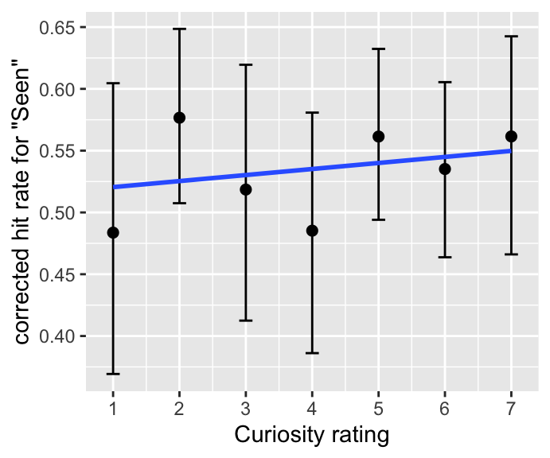

## 3.3 Testing the relationship between mean accuracy of item memory and curiosity rating

Build models with item memory accuracy as $y$ and examine effects of curiosity rating by including it into the model and then comparing the model fits.

- `baseline.rating` is the model with only an intercept, showing no change in item memory as a function of curiosity rating.
- `rating.intercept` is the model with $\small EncodingRating$ included, showing the effects of curiosity rating.
- `rating.slope` is the model allowing the slope (i.e., relationship between item memory and curiosity rating) varying across participants.

```
##                  Model df        AIC       BIC   logLik   Test   L.Ratio
## baseline.rating      1  3 -14.568201 -4.027915 10.28410
## rating.intercept     2  4 -12.948103  1.105612 10.47405 1 vs 2 0.3799020
## rating.slope         3  6  -9.795467 11.285106 10.89773 2 vs 3 0.8473637
##                  p-value
## baseline.rating
## rating.intercept  0.5377
## rating.slope      0.6546
```

```
## Linear mixed-effects model fit by maximum likelihood
##  Data: inside.hit.rate.per.room
##         AIC      BIC   logLik
##   -9.795467 11.28511 10.89773
##
## Random effects:
##  Formula: ~1 + CurRating | SubjectNo
##  Structure: General positive-definite, Log-Cholesky parametrization
##             StdDev     Corr
## (Intercept) 0.15853298 (Intr)
## CurRating   0.01763379 -0.03
## Residual    0.19823394
##
## Fixed effects: SAcc ~ CurRating
##                 Value  Std.Error  DF   t-value p-value
## (Intercept) 0.5219693 0.04191719 205 12.452394  0.0000
## CurRating   0.0036303 0.00763466 205  0.475499  0.6349
##  Correlation:
##           (Intr)
## CurRating -0.707
##
## Standardized Within-Group Residuals:
##         Min          Q1         Med          Q3         Max
## -2.48495288 -0.66816924 -0.02967538  0.62790897  2.40194813
##
## Number of Observations: 248
## Number of Groups: 42
```

## 3.4 Check the curiosity groups

### 3.4.1 Separate the groups according to the rating

- *High*: curiosity rating > 4
- *Low*: curiosity rating < 4
- For curiosity rating = 4, discarded

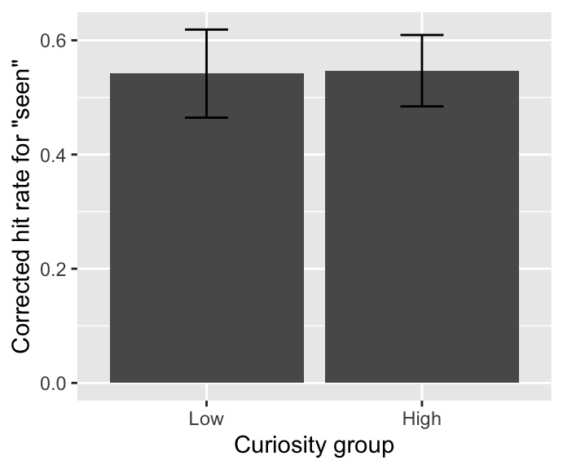

```
## Linear mixed-effects model fit by maximum likelihood
##  Data: inside.hit.rate.curiosity.group
##         AIC       BIC   logLik
##   -16.43881 -2.146652 14.21941
##
## Random effects:
##  Formula: ~1 + CurGrp | SubjectNo
##  Structure: General positive-definite, Log-Cholesky parametrization
##             StdDev     Corr
## (Intercept) 0.22533515 (Intr)
## CurGrpHigh  0.16212895 -0.525
## Residual    0.08491587
##
## Fixed effects: SAcc ~ CurGrp
##                 Value  Std.Error DF   t-value p-value
## (Intercept) 0.5371283 0.03884842 41 13.826260  0.0000
## CurGrpHigh  0.0101446 0.03297325 37  0.307661  0.7601
##  Correlation:
##            (Intr)
## CurGrpHigh -0.576
##
## Standardized Within-Group Residuals:
##         Min          Q1         Med          Q3         Max
## -1.30511015 -0.30628872 -0.08528854  0.35975809  1.02284898
##
## Number of Observations: 80
## Number of Groups: 42
```

#### 3.4.1.1 Curiosity groups and temporal order of the objects

##### 3.4.1.1.1 Check the data

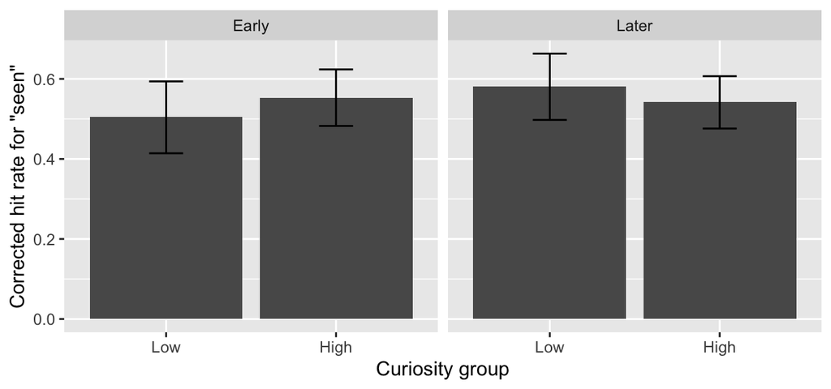

```
##    CurGrp ObjOrdGrp      Mean        SD  N
## 1:   High     Early 0.5529547 0.2497881 42
## 2:   High     Later 0.5415189 0.2315488 42
## 3:    Low     Later 0.5813492 0.2649450 38
## 4:    Low     Early 0.5045948 0.2913117 38
```

```
##           Model df        AIC      BIC   logLik   Test  L.Ratio p-value
## baseline      1  8 -12.245690 12.35570 14.12284
## ord.model     2  9 -11.212137 16.46443 14.60607 1 vs 2 0.966447  0.3256
## cur.model     3 10  -9.311677 21.44006 14.65584 2 vs 3 0.099540  0.7524
## int.model     4 11 -10.728697 23.09821 16.36435 3 vs 4 3.417020  0.0645
```

```
## Linear mixed-effects model fit by maximum likelihood
##  Data: inside.hit.rate.item.order.curiosity
##        AIC      BIC   logLik
##   -10.7287 23.09822 16.36435
##
## Random effects:
##  Formula: ~1 + CurGrp + ObjOrdGrp | SubjectNo
##  Structure: General positive-definite, Log-Cholesky parametrization
##                StdDev    Corr
## (Intercept)    0.2289268 (Intr) CrGrpH
## CurGrpHigh     0.1400416 -0.453
## ObjOrdGrpLater 0.1271239 -0.306 -0.159
## Residual       0.1447984
##
## Fixed effects: SAcc ~ ObjOrdGrp + CurGrp + ObjOrdGrp:CurGrp
##                                Value  Std.Error  DF   t-value p-value
## (Intercept)                0.4993456 0.04377108 115 11.408118  0.0000
## ObjOrdGrpLater             0.0754568 0.03944656 115  1.912885  0.0582
## CurGrpHigh                 0.0536091 0.04033654 115  1.329046  0.1865
## ObjOrdGrpLater:CurGrpHigh -0.0868925 0.04674827 115 -1.858733  0.0656
##  Correlation:
##                           (Intr) ObjOGL CrGrpH
## ObjOrdGrpLater            -0.460
## CurGrpHigh                -0.561  0.320
## ObjOrdGrpLater:CurGrpHigh  0.282 -0.630 -0.578
##
## Standardized Within-Group Residuals:
##         Min          Q1         Med          Q3         Max
## -2.37205709 -0.56499643  0.06027004  0.51591849  1.91421879
##
## Number of Observations: 160
## Number of Groups: 42
```

##### 3.4.1.1.2 *Post hoc*

```
##
##   Simultaneous Tests for General Linear Hypotheses
##
## Fit: lme.formula(fixed = SAcc ~ ObjOrdGrp + CurGrp + ObjOrdGrp:CurGrp,
##     data = inside.hit.rate.item.order.curiosity, random = ~1 +
##         CurGrp + ObjOrdGrp | SubjectNo, method = "ML", na.action = na.exclude,
##     control = list(msMaxIter = 500, opt = "optim", msVerbose = FALSE))
##
## Linear Hypotheses:
##                          Estimate Std. Error z value Pr(>|z|)
## Early: High vs. Low == 0  0.05361    0.03983   1.346    0.178
## Late:  High vs. Low == 0 -0.03328    0.03991  -0.834    0.404
## (Adjusted p values reported -- none method)
```

### 3.4.2 Separate the groups according to the median rating of each participant

- *High*: curiosity rating > median of the participant
- *Low*: curiosity rating < median of the participant

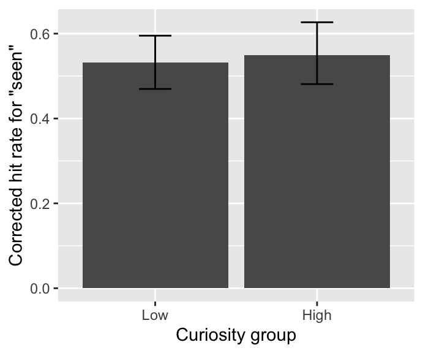

```
## Linear mixed-effects model fit by maximum likelihood
##  Data: inside.hit.rate.curiosity.group.median
##         AIC       BIC   logLik
##   -24.85233 -10.33929 18.42617
##
## Random effects:
##  Formula: ~1 + CurGrpMedian | SubjectNo
##  Structure: General positive-definite, Log-Cholesky parametrization
##                  StdDev     Corr
## (Intercept)      0.19491370 (Intr)
## CurGrpMedianHigh 0.15807034 -0.328
## Residual         0.07996794
##
## Fixed effects: SAcc ~ CurGrpMedian
##                      Value  Std.Error DF   t-value p-value
## (Intercept)      0.5319951 0.03290758 41 16.166338  0.0000
## CurGrpMedianHigh 0.0153466 0.03066708 40  0.500427  0.6195
##  Correlation:
##                  (Intr)
## CurGrpMedianHigh -0.399
##
## Standardized Within-Group Residuals:
##         Min          Q1         Med          Q3         Max
## -0.94708723 -0.32346870 -0.01666045  0.34603571  1.38544682
##
## Number of Observations: 83
## Number of Groups: 42
```

#### 3.4.2.1 Curiosity groups and temporal order of the objects

##### 3.4.2.1.1 Check the data

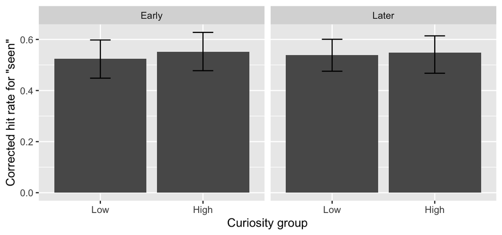

```
##    CurGrpMedian ObjOrdGrp      Mean        SD  N
## 1:          Low     Early 0.5247200 0.2567998 42
## 2:         High     Early 0.5516841 0.2593437 41
## 3:         High     Later 0.5476190 0.2385445 41
## 4:          Low     Later 0.5392703 0.2225686 42
```

```
##           Model df       AIC        BIC   logLik   Test    L.Ratio p-value
## baseline      1  8 -43.88802 -18.992119 29.94401
## ord.model     2  9 -41.95197 -13.944083 29.97599 1 vs 2 0.06395217  0.8004
## cur.model     3 10 -40.19118  -9.071300 30.09559 2 vs 3 0.23920447  0.6248
## int.model     4 11 -38.35665  -4.124779 30.17832 3 vs 4 0.16546720  0.6842
```

```
## Linear mixed-effects model fit by maximum likelihood
##  Data: inside.hit.rate.item.order.curiosity.median
##         AIC       BIC   logLik
##   -38.35665 -4.124779 30.17832
##
## Random effects:
##  Formula: ~1 + CurGrpMedian + ObjOrdGrp | SubjectNo
##  Structure: General positive-definite, Log-Cholesky parametrization
##                  StdDev    Corr
## (Intercept)      0.2069600 (Intr) CrGrMH
## CurGrpMedianHigh 0.1472282 -0.270
## ObjOrdGrpLater   0.1210865 -0.403 -0.028
## Residual         0.1265009
##
## Fixed effects: SAcc ~ ObjOrdGrp + CurGrpMedian + ObjOrdGrp:CurGrpMedian
##                                      Value  Std.Error  DF   t-value
## (Intercept)                      0.5247200 0.03788694 121 13.849627
## ObjOrdGrpLater                   0.0145503 0.03374244 121  0.431216
## CurGrpMedianHigh                 0.0228349 0.03654186 121  0.624898
## ObjOrdGrpLater:CurGrpMedianHigh -0.0160162 0.03983287 121 -0.402084
##                                 p-value
## (Intercept)                      0.0000
## ObjOrdGrpLater                   0.6671
## CurGrpMedianHigh                 0.5332
## ObjOrdGrpLater:CurGrpMedianHigh  0.6883
##  Correlation:
##                                 (Intr) ObjOGL CrGrMH
## ObjOrdGrpLater                  -0.498
## CurGrpMedianHigh                -0.427  0.307
## ObjOrdGrpLater:CurGrpMedianHigh  0.259 -0.581 -0.545
##
## Standardized Within-Group Residuals:
##         Min          Q1         Med          Q3         Max
## -1.92033863 -0.60034156 -0.01327052  0.55782547  1.61304999
##
## Number of Observations: 166
## Number of Groups: 42
```